# 012 Comparison of PRM and MS1 data

Clara Jégousse

2022-12-09

## PRM

CJ 2022.12.09

Objective is to tidy the data sets in order to compare PRM and MS1 data.

### Load PRM data

Let’s load the PRM (parallel reaction monitoring?) data

```r
prm_filepath = paste0(here::here(), "/data/raw/M_oryzae_PRM_TEMP_07_with_spectra_refined_Guy11_deltaPmk1_timecourse_for_thesis_copy.xlsx")
prm_data = readxl::read_xlsx(prm_filepath)
```

### Tidy data PRM data

We tidy the data with the following steps:

1. pivot/melt the data using the samples names `Replicate names`
2. select the columns of interests
3. format/rename column names to be only in lowercase
4. format/rename column names without white spaces
5. Split the `replicate_name` into different columns for “genotype”, “timepoint”, “bio_rep”, “tech_rep”, “misc” using `_` as the separator
6. replace “Spore” to `0` for consistency in variable `timepoint`
7. format variable bio_rep
8. format variable tech_rep
9. select/order the columns of interests

```r
tidy_prm_data = prm_data %>%
  tidyr::pivot_longer(cols = Guy11_Spores_r1_t2_02_ncr200619_01:dpmk1_6_r3_t2_72_ncr200619_36,
    names_to = 'Replicate Name', values_to = 'Total Area') %>%
  dplyr::select( `Replicate Name`, `Molecule List Name`, `Total Area`, `Peptide Modified Sequence`) %>%
  dplyr::rename_with(tolower) %>%
  dplyr::rename_with( ~ gsub(" ", "_", .x)) %>%
  dplyr::rename(gene_id = molecule_list_name) %>%
  dplyr::rename(peptide = peptide_modified_sequence) %>%
  tidyr::separate(replicate_name, into = c("genotype", "timepoint", "bio_rep", "tech_rep", "misc"), sep="_") %>%
  dplyr::mutate(
    timepoint = as.numeric(dplyr::if_else(timepoint == 'Spores', "0", timepoint)),
    bio_rep = as.numeric(stringr::str_sub(bio_rep, 2,-1)),
    tech_rep = as.numeric(stringr::str_sub(tech_rep, 2,-1))
  ) %>%
  dplyr::select(gene_id, peptide, genotype, timepoint, bio_rep, tech_rep, total_area)
```

### Format peptide sequences in PRM data

According to Frank Menke, we should remove the phosphorylation positions and other information and only keep the amino-acid sequence.

```r
clean_tidy_prm_data = tidy_prm_data %>%
  mutate(peptide = gsub("\\[([^]]+)\\]", "", peptide))
```

### Combine technical replicates

```r
mean_tr_prm_data = clean_tidy_prm_data %>%
  dplyr::group_by(.data$gene_id, .data$peptide, .data$genotype, .data$timepoint, .data$bio_rep) %>%
  dplyr::summarize(mean_tr_total_area = mean(.data$total_area, na.rm = TRUE) )
```

[output not shown]

### Convert to matrix

Convert data frame to matrix

1. pivot tidy data frame into wide data frame
2. save row and column information
3. convert data frame into matrix
4. list the row information and the matrix

```r
mean_tr_prm_matrix <- mean_tr_prm_data %>%
    tidyr::pivot_wider(names_from = c(genotype, timepoint, bio_rep),
      values_from = mean_tr_total_area) %>%
    as.matrix()

row_info <- mean_tr_prm_matrix[,c("gene_id", "peptide")]
col_info <- colnames(mean_tr_prm_matrix[,3:length(colnames(mean_tr_prm_matrix))])

matrix <- matrix(as.numeric(mean_tr_prm_matrix[,3:ncol(mean_tr_prm_matrix)]),
  nrow = nrow(mean_tr_prm_matrix) )
colnames(matrix) <- col_info

mdata = list( row_info = row_info, data = matrix )
```

### Replace missing values

Let’s define a function to extract the minimum values so that we can extract all the lowest values for each row of the dataset.

```r
min_peptide_values <- function(d){
  apply(d$data, MARGIN = 1, min, na.rm = TRUE)
}

lowest_vals <- min_peptide_values(mdata)
```

Let’s define a function to replace NA values with lowest values

```r
replace_vals <- function(x, lowest_vals){
  to_replace <- which(is.na(x))
  x[to_replace] <- lowest_vals[to_replace]
  return(x)
}
```

Create a new matrix with no NA

```r
mdata$data_complete = cbind(
  apply(mdata$data %>% as.data.frame() %>%
    select(.,contains("Guy11")),
    MARGIN = 2, replace_vals, lowest_vals),
  apply(mdata$data %>% as.data.frame() %>%
    select(.,contains("dpmk")),
    MARGIN = 2, replace_vals, lowest_vals))
```

Let’s display the heatmap

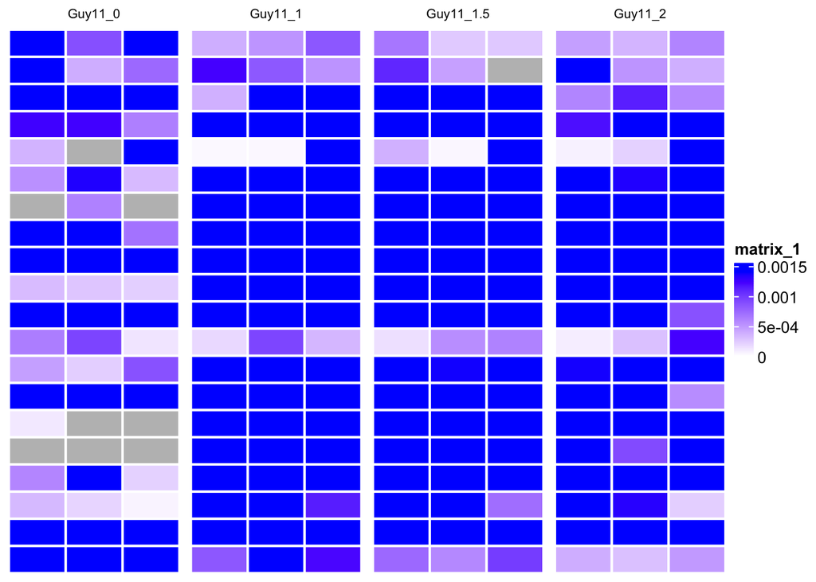

```r
m <- mdata$data
rownames(m) <- mdata$row_info[,'peptide']
colnames(m) <- colnames(mdata$data)

# have a look at a subset of the matrix
m = m[1:20, 1:12]

col_fun = circlize::colorRamp2(c(0, 0.0014), c( "white", "blue"))

col_split = factor(paste(stringr::str_split(colnames(m), "_", n = 3,
  simplify = TRUE)[,1], stringr::str_split(colnames(m), "_", n = 3,
    simplify = TRUE)[,2], sep =  "_"))

hm_na = ComplexHeatmap::Heatmap(m,
  column_split = col_split,
  column_title_gp = grid::gpar(fontsize = 8),
  column_gap = grid::unit(0.25, "cm"),
  column_order = colnames(m),
  show_column_names = FALSE,
  row_order = rownames(m),
  show_row_names = FALSE,
  rect_gp = grid::gpar(col = "white", lwd = 2 ),
  col = col_fun )

m <- mdata$data_complete
rownames(m) <- mdata$row_info[,'peptide']
colnames(m) <- colnames(mdata$data)

# have a look at a subset of the matrix
m = m[1:20, 1:12]

col_fun = circlize::colorRamp2(c(0, 0.0014), c( "white", "blue"))

col_split = factor(paste(stringr::str_split(colnames(m), "_", n = 3,
  simplify = TRUE)[,1], stringr::str_split(colnames(m), "_", n = 3,
    simplify = TRUE)[,2], sep =  "_"))

hm_complete = ComplexHeatmap::Heatmap(m,
  column_split = col_split,
  column_title_gp = grid::gpar(fontsize = 8),
  column_gap = grid::unit(0.25, "cm"),
  column_order = colnames(m),
  show_column_names = FALSE,
  row_order = rownames(m),
  show_row_names = FALSE,
  rect_gp = grid::gpar(col = "white", lwd = 2 ),
  col = col_fun )

hm_na
```

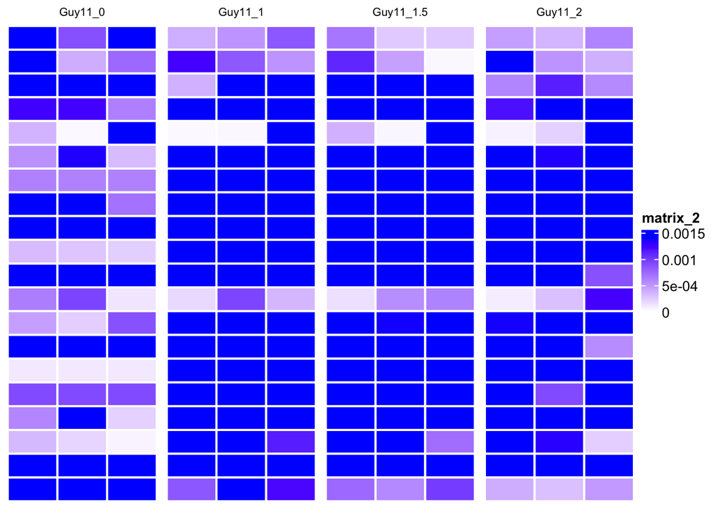

```r
hm_complete
```

### Scaling

We scale from 0 to 1

```r
maxs <- apply(mdata$data_complete, 2, max)
mins <- apply(mdata$data_complete, 2, min)

mdata$data_scaled = scale(mdata$data_complete, center = mins, scale = maxs - mins)
```

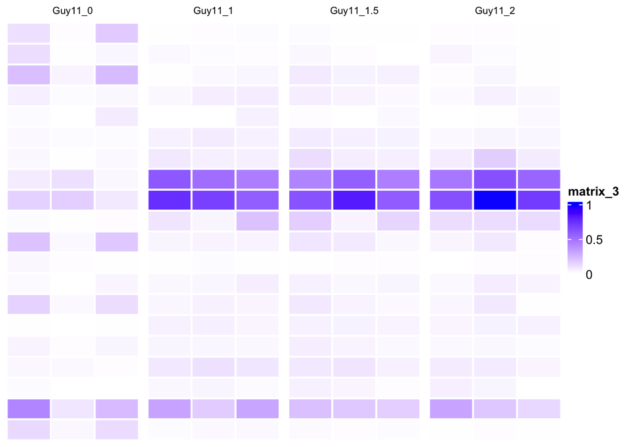

```r
m <- mdata$data_scaled
rownames(m) <- mdata$row_info[,'peptide']
colnames(m) <- colnames(mdata$data)

# have a look at a subset of the matrix
m = m[1:20, 1:12]

col_fun = circlize::colorRamp2(c(0, 1), c( "white", "blue"))

col_split = factor(paste(stringr::str_split(colnames(m), "_", n = 3,
  simplify = TRUE)[,1], stringr::str_split(colnames(m), "_", n = 3,
    simplify = TRUE)[,2], sep =  "_"))

hm_scaled = ComplexHeatmap::Heatmap(m,
  column_split = col_split,
  column_title_gp = grid::gpar(fontsize = 8),
  column_gap = grid::unit(0.25, "cm"),
  column_order = colnames(m),
  show_column_names = FALSE,
  row_order = rownames(m),
  show_row_names = FALSE,
  rect_gp = grid::gpar(col = "white", lwd = 2 ),
  col = col_fun )

hm_scaled
```

### Combine biological replicates

```r
clean_tidy_prm_scaled_data = cbind(mdata$row_info, mdata$data_scaled) %>% as.data.frame() %>%
  tidyr::pivot_longer(cols = Guy11_0_1:dpmk1_6_3,
    names_to = 'replicate_name', values_to = 'abundance') %>%
  tidyr::separate(replicate_name, into = c("genotype", "timepoint", "bio_rep"), sep="_")
```

```r
clean_tidy_prm_data = clean_tidy_prm_scaled_data %>%
  dplyr::group_by(gene_id, peptide, genotype, timepoint) %>%
  dplyr::summarize(abundance = mean(as.numeric(abundance), na.rm = TRUE) )
```

### Write clean tidy scaled data

Write the tidy PRM data.

```r
readr::write_csv(clean_tidy_prm_data, here::here("data", "cleaned", "012_clean_tidy_prm_scaled_data.csv"))
```

## MS1

### Load MS1 data

Let’s load the MS1 (mass spectrometry 1?) data

```r
ms1_filepath = paste0(here::here(), "/data/raw/Nrc210121_rgm2r_1to6hrsMS1Q.xlsx")
ms1_data = readxl::read_xlsx(ms1_filepath, trim_ws = TRUE)
```

### Tidy data

```r
tidy_ms1_data = ms1_data %>%
  select("Annotated Sequence", "Modifications", "Master Protein Accessions", contains("(grouped):")) %>%
  dplyr::rename_with(tolower) %>%
  dplyr::rename_with( ~ gsub(" ", "_", .x)) %>%
  dplyr::rename_with( ~ gsub(",", "", .x)) %>%
  dplyr::rename_with( ~ gsub(":", "", .x)) %>%
  dplyr::rename_with( ~ gsub("\\(", "", .x)) %>%
  dplyr::rename_with( ~ gsub("\\)", "", .x)) %>%
  tidyr::pivot_longer(cols = abundances_grouped_0_dpmk1:abundances_grouped_6_guy11,
    names_to = 'replicate_name', values_to = 'total_area') %>%
  tidyr::separate(replicate_name, into = c("abund", "grouped", "timepoint", "genotype"), sep="_") %>%
  dplyr::rename(gene_id = master_protein_accessions) %>%
  dplyr::rename(peptide = annotated_sequence) %>%
  mutate(total_area = as.numeric(total_area)) %>%
  dplyr::select(gene_id, peptide, modifications, genotype, timepoint, total_area)
```

### Format peptide sequences

```r
clean_tidy_ms1_data = tidy_ms1_data  %>%
  mutate(peptide = gsub("^\\[([^]]+)\\].", "", peptide)) %>%
  mutate(peptide = gsub(".\\[([^]]+)\\]$", "", peptide))
```

### Select peptides with PRM and MS1 values

Check the number of peptides in MS1 data

```r
clean_tidy_ms1_data$peptide %>% unique() %>% length()
```

```
## [1] 2830
```

```r
clean_tidy_prm_data$peptide %>% unique() %>% length()
```

```
## [1] 191
```

There are 2830 peptides in MS1 and 191 in PRM.

```r
prm_peptides = clean_tidy_prm_data$peptide %>% unique()

selected_clean_tidy_ms1_data = clean_tidy_ms1_data %>%
 filter(peptide %in% prm_peptides)

selected_clean_tidy_ms1_data$peptide %>% unique() %>% length()
```

```
## [1] 88
```

There are 88 peptides in MS1 that are also in PRM.

### Convert to matrix

```r
selected_clean_ms1_matrix = selected_clean_tidy_ms1_data %>%
    tidyr::pivot_wider(names_from = c(genotype, timepoint),
      values_from = total_area) %>%
    as.matrix()

row_info = selected_clean_ms1_matrix[,c("gene_id", "peptide", "modifications")]
col_info = colnames(selected_clean_ms1_matrix[,4:length(colnames(selected_clean_ms1_matrix))])

ms1_matrix = apply(matrix(selected_clean_ms1_matrix[,4:ncol(selected_clean_ms1_matrix)],
  nrow = nrow(selected_clean_ms1_matrix)), 2, as.numeric)

colnames(ms1_matrix) <- col_info

ms1_mdata = list( row_info = row_info, data = ms1_matrix )
```

### Replace missing values

Let’s re-use the functions we defined earlier to extract the minimum values and to replace NA values with lowest values.

```r
lowest_vals <- min_peptide_values(ms1_mdata)
```

Create a new matrix with no NA

```r
ms1_mdata$data_complete = cbind(
  apply(ms1_mdata$data %>% as.data.frame() %>%
    select(.,contains("Guy11")),
    MARGIN = 2, replace_vals, lowest_vals),
  apply(ms1_mdata$data %>% as.data.frame() %>%
    select(.,contains("dpmk")),
    MARGIN = 2, replace_vals, lowest_vals))
```

### Scaling

We scale from 0 to 1

```r
maxs <- apply(ms1_mdata$data_complete, 2, max)
mins <- apply(ms1_mdata$data_complete, 2, min)

ms1_mdata$data_scaled = scale(ms1_mdata$data_complete, center = mins, scale = maxs - mins)
```

### Write clean tidy scaled data

Write the tidy MS1 data.

```r
clean_tidy_ms1_scaled_data = cbind(ms1_mdata$row_info, ms1_mdata$data_scaled) %>% as.data.frame() %>%
  tidyr::pivot_longer(cols = guy11_0:dpmk1_6,
    names_to = 'replicate_name', values_to = 'abundance') %>%
  tidyr::separate(replicate_name, into = c("genotype", "timepoint"), sep="_")
```

```r
readr::write_csv(clean_tidy_ms1_scaled_data, here::here("data", "cleaned", "012_clean_tidy_ms1_scaled_data.csv"))
```

## COMPARISON

Let’s prep the datasets

```r
prm_data = clean_tidy_prm_data %>%
  mutate(tech_pep = paste("PRM", peptide)) %>%
  select(tech_pep, gene_id, peptide, genotype, timepoint, abundance)

ms1_data = clean_tidy_ms1_scaled_data %>%
  mutate(tech_pep_modif = paste("MS1", peptide, modifications)) %>%
  select(tech_pep_modif, gene_id, peptide, modifications, genotype, timepoint, abundance)
```

## Visualisation

```r
pdf_filename = here::here("graphics", "012-all-prm-ms1-comparison-plots.pdf")
ggexport(plot_list, filename = pdf_filename)
```

```
## file saved to /Users/jegoussc/GitHub/PD_PRO_1499_06122021_PRM2/graphics/012-all-prm-ms1-comparison-plots.pdf
```